# Modulo 6 - Seconda serie

Soluzioni

Author

Ottavia Epifania

# 1 Introduzione

In questa serie di esercizi si dovrà rianalizzare i dati presentati nel Laboratorio del Modulo didattico 3 (LABM3: Abilità spazio-simboliche in età infantile: 3-4 anni) questa volta sostituendo l’analisi statistica descrittiva con la corrispondente analisi inferenziale. I dati sono i dati chiamati `DataAS.csv`

# 2 Esercizi

Ripetere le analisi degli esercizi da 1 a 3 descritti nel LABM3 utilizzando le opportune tecniche inferenziali.

## 2.1

Studiare se vi sia una qualche associazione tra le due fasce di età ed il fatto che la persona (il bambino o la bambina) ottenga un numero di risposte corrette superiori o uguali alla soglia minima 10 per quanto riguarda gli stimoli nello scenario macchinine.

```r
dati <- read.csv2("DataAS.csv")

head(dati)
```

```
  Sgg S  E a1b1 a1b2 a2b1 a2b2
1   1 f 37    6    4    7    6
2   2 f 38    5    3    8    5
3   3 f 36    5    2    6    7
4   4 f 36    6    3    6    8
5   5 f 39    7    2    5    8
6   6 f 39    4    4    6    6
```

```r
ECat <- dati$E
ECat[(dati$E >= 36) & (dati$E <= 43)] <- 1
ECat[(dati$E >= 44) & (dati$E <= 51)] <- 2
SM10 <- rep(0,60)
SM10[(dati$a1b1+dati$a1b2)>=10] <- 1
myT <- table(ECat,SM10)
rownames(myT) <- c("[36-43]","[44-51]")
colnames(myT) <- c("P<10","P>=10")
myT  # I bambini più grandi hanno una maggiore probabilità di
```

```
         SM10
ECat      P<10 P>=10
  [36-43]   23     7
  [44-51]    4    26
```

```r
   # superare la soglia minima 10

chisq.test(myT)
```

```
    Pearson's Chi-squared test with Yates' continuity correction

data:  myT
X-squared = 21.818, df = 1, p-value = 2.997e-06
```

## 2.2

Ripetere l’analisi questa volta utilizzando come riferimento gli stimoli associati allo scenario casa delle bambole (si consideri sempre la stessa soglia minima pari a 10).

```r
SB10 <- rep(0,60)
SB10[(dati$a2b1+dati$a2b2)>=10] <- 1
myT1 <- table(ECat,SB10)
rownames(myT1) <- c("[36-43]","[44-51]")
colnames(myT1) <- c("P<10","P>=10")
myT1  # non sembra esserci una grande differenza tra le due età
```

```
         SB10
ECat      P<10 P>=10
  [36-43]    4    26
  [44-51]    0    30
```

```r
chisq.test(myT1)
```

```
    Pearson's Chi-squared test with Yates' continuity correction

data:  myT1
X-squared = 2.4107, df = 1, p-value = 0.1205
```

## 2.3

Ripetere le analisi precedenti questa volta considerando la variabile genere sessuale al posto della variabile fasce di età.

```r
GEN <- dati$S
myT2 <- table(GEN,SM10)
myT3 <- table(GEN,SB10)
rownames(myT2) <- c("F","M")
colnames(myT2) <- c("P<10","P>=10")
rownames(myT3) <- c("F","M")
colnames(myT3) <- c("P<10","P>=10")
myT2
```

```
   SM10
GEN P<10 P>=10
  F   13    17
  M   14    16
```

```r
chisq.test(myT2)
```

```
    Pearson's Chi-squared test with Yates' continuity correction

data:  myT2
X-squared = 0, df = 1, p-value = 1
```

```r
myT3
```

```
   SB10
GEN P<10 P>=10
  F    0    30
  M    4    26
```

```r
chisq.test(myT3)
```

```
    Pearson's Chi-squared test with Yates' continuity correction

data:  myT3
X-squared = 2.4107, df = 1, p-value = 0.1205
```

## 2.4

Verificare se vi sia una differenza statisticamente significativa tra il numero di risposte corrette ottenute dai partecipanti nello scenario macchinine ed il numero di risposte corrette ottenute dai partecipanti nello scenario casa delle bambole (con $\alpha = 0.05$).

```r
RCa1 <- dati$a1b1 + dati$a1b2
RCa2 <- dati$a2b1 + dati$a2b2

t.test(RCa1,RCa2,paired=T)
```

```
    Paired t-test

data:  RCa1 and RCa2
t = -8.834, df = 59, p-value = 2.162e-12
alternative hypothesis: true mean difference is not equal to 0
95 percent confidence interval:
 -4.313228 -2.720105
sample estimates:
mean difference
      -3.516667
```

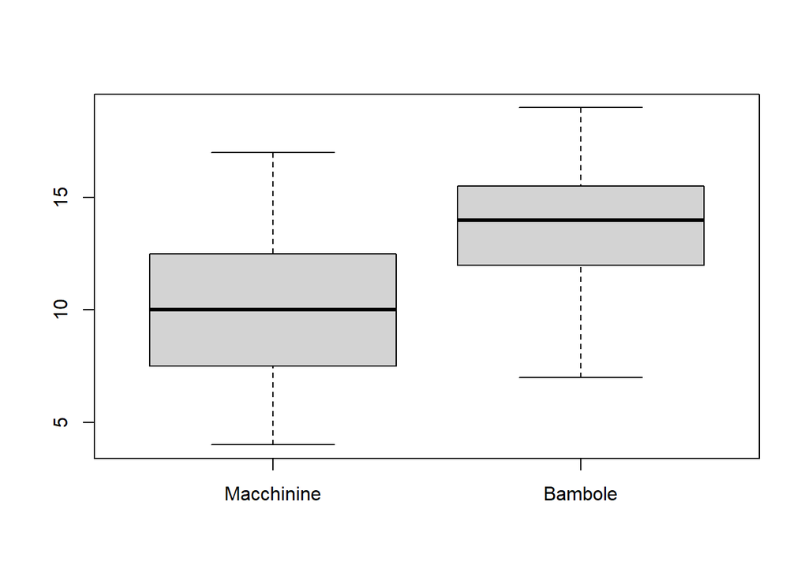

```r
boxplot(RCa1, RCa2, names = c("Macchinine", "Bambole"))
```

## 2.5

Verificare se il numero di risposte corrette ottenute dai partecipanti nello scenario senza repliche sia significativamente superiore al numero di risposte corrette ottenute dai partecipanti nello scenario con repliche (nota: con $\alpha = 0.20$).

```r
RCb1 <- dati$a1b1 + dati$a2b1
RCb2 <- dati$a1b2 + dati$a2b2

t.test(RCb1,RCb2,paired=T,alternative="greater")
```

```
    Paired t-test

data:  RCb1 and RCb2
t = 7.5057, df = 59, p-value = 1.881e-10
alternative hypothesis: true mean difference is greater than 0
95 percent confidence interval:
 2.500495      Inf
sample estimates:
mean difference
       3.216667
```

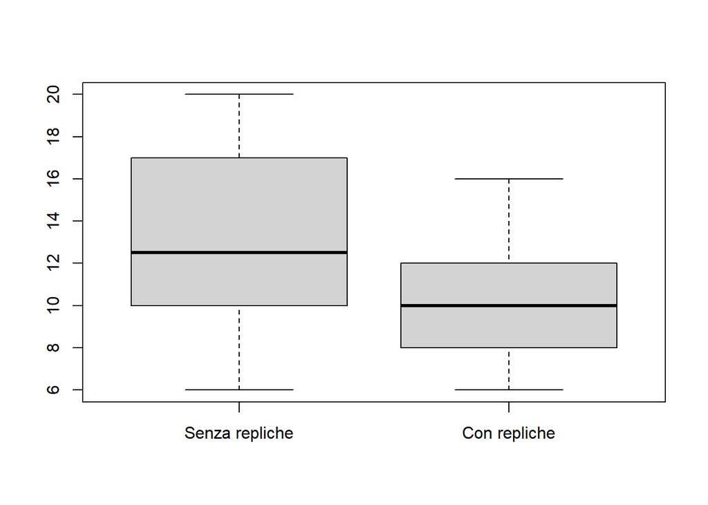

```r
boxplot(RCb1, RCb2, names = c("Senza repliche", "Con repliche"))
```

## 2.6

Verificare se la proporzione di bambine che superano la soglia minima 10 nello scenario macchinine sia significativamente inferiore alla proporzione di bambini che superano la soglia minima 10 nello stesso scenario (con $\alpha = 0.05$).

```r
nFa1 <- sum(RCa1[dati$S=="f"] >= 10)
nMa1 <- sum(RCa1[dati$S=="m"] >= 10)

nFa1
```

```
[1] 17
```

```r
nMa1
```

```
[1] 16
```

```r
prop.test(c(nFa1,nMa1),c(30,30),alternative="less")
```

```
    2-sample test for equality of proportions with continuity correction

data:  c(nFa1, nMa1) out of c(30, 30)
X-squared = 4.7079e-31, df = 1, p-value = 0.5
alternative hypothesis: less
95 percent confidence interval:
 -1.0000000  0.2778333
sample estimates:
   prop 1    prop 2
0.5666667 0.5333333
```